# Vertical Profile Feature: Vertical Profile of Temperature at Zurich Airport

The following notebook demonstrates the full workflow to access, process and visualize a vertical profile of ICON-CH1-EPS temperature data.

[figure not shown]

The data is retrieved using [Polytope](https://polytope.readthedocs.io/en/latest/), a feature extraction software developed by ECMWF. It applies concepts of computational geometry to extract n-dimensional polygons (also known as polytopes) from datacubes, such as a vertical profile. To access MeteoSwiss' operational ICON-CH1-EPS and ICON-CH2-EPS model data, [meteodata-lab](https://meteoswiss.github.io/meteodata-lab/) provides a wrapper around the polytope client that simplifies the request API. Follow the instructions to learn more about model data access via Polytope.

## Installation

Follow the instructions in [README.md](https://github.com/MeteoSwiss/nwp-fdb-polytope-demo/blob/main/README.md#Installation-1) to install the necessary dependencies.

## Configuring Access to Polytope

To access ICON data via MeteoSwiss's Polytope, you need a Polytope offline token provided by MeteoSwiss. If you do not already have a token, you can request one [here](https://meteoswiss.atlassian.net/wiki/spaces/IW2/pages/327780397/Polytope#Offline-token-authentication). Then, create a new `config.yml` file based on `config_example.yml`, and replace <meteoswiss_key> with your access token there.

```python
import os
import yaml

def load_config(path="config.yml"):
    if not os.path.exists(path):
        raise FileNotFoundError("Missing config.yml. Please create one based on config_example.yml.")
    with open(path, "r") as f:
        return yaml.safe_load(f)

config = load_config()

#ICON-CSCS Polytope credentials
os.environ["POLYTOPE_USER_KEY"] = config["meteoswiss"]["key"]
os.environ["POLYTOPE_ADDRESS"] = "https://polytope-depl.mchml.cscs.ch"
```

## Selecting date and time of the forecast

The realtime FDB typically **includes only the most recent day of forecasts**. Therefore, it is necessary to specify the current date and select a corresponding forecast time in the past.

```python
from datetime import datetime, timedelta

# Current time
now = datetime.now()

# Subtract 12 hours
past_time = now - timedelta(hours=12)

# Round down to the nearest multiple of 6
rounded_hour = (past_time.hour // 6) * 6
rounded_time = past_time.replace(hour=rounded_hour, minute=0, second=0, microsecond=0)

# Format as YYYYMMDD and HHMM
date = rounded_time.strftime('%Y%m%d')
time = rounded_time.strftime('%H%M')
date,time
```

```
('20251015', '1800')
```

## Select the geolocation

We’ll request a vertical profile at Zurich Airport (WGS84 coordinates).

To use the polytope feature, it is necessary to rotate the given data point (here Zurich Airport) since the data source accessed by Polytope is stored on a rotated grid. By using a South Pole rotation with a reference of longitude 10° and latitude of -43°, we are able to access the desired data point.

> **IMPORTANT**: The function `transform_point()` expects first longitude and then latitude.

```python
import cartopy.crs as ccrs

# point for vertical profile
zrh_geo_point = (8.565074, 47.453928)  # (longitude, latitude) in WGS84

# South pole rotation of lon=10, latitude=-43
rotated_crs = ccrs.RotatedPole(
    pole_longitude=190, pole_latitude=43
)

# Convert a point from geographic to rotated coordinates
geo_crs = ccrs.PlateCarree()
rotated_point = rotated_crs.transform_point(zrh_geo_point[0], zrh_geo_point[1], geo_crs)
```

## Define the request

Once the data is rotated, we need to define a mars request using [meteodata-lab](https://polytope.readthedocs.io/en/latest/). The `feature` attribute allows you to extract **only the relevant data at the given point(s)**. Thus, the amount of data that is retrieved from storage is significantly reduced. For the "vertical profile" `feature` the following dictionary is needed.

```python
feature={
    "type" : "verticalprofile",
    "points" : [rotated_point],
    "axes" : "levelist"
}
```

Finally, we can define the request. This example fetches **temperature** from **ICON-CH1-EPS** at the **pressure levels** 100 to 850, for the **control forecast**, at the selected run date/time.

- `type="pf"` — perturbed member (requires `number`).
- `type="cf"` — control forecast (no `number`).

```python
from meteodatalab import mars

request = mars.Request(
    param="T",
    date=date,
    time=time,
    model=mars.Model.ICON_CH1_EPS,
    levtype=mars.LevType.PRESSURE_LEVEL,
    type="cf",
    step=0,
    levelist=range(100,900,50),
    feature=feature
)
```

## Data retrieval

Now we use [earthkit.data](https://earthkit-data.readthedocs.io/en/latest/) to load the data and convert it into an [xarray.Dataset](https://docs.xarray.dev/en/stable/generated/xarray.Dataset.html).

```python
import earthkit.data as ekd
ds = ekd.from_source(
    "polytope",
    "mchgj",
    request.to_polytope(),
    stream=False
).to_xarray()
```

[output not shown]

## Plotting

We use the library [earthkit.plots](https://earthkit-plots.readthedocs.io/en/latest/) to plot the data.

```python
from earthkit.plots.interactive import Chart

da = ds["t"].to_dataframe().reset_index()

chart = Chart()

# convert to degree Celsius
chart.line(x=da["t"].values - 273.15, y=da["levelist"].values)

# set axis names
chart.fig.update_layout(xaxis1={"title": "Temperature (°C)"})
chart.fig.update_layout(yaxis1={"title": "Pressure levels (hPa)"})
chart.fig.update_yaxes(autorange="reversed")
chart.fig.update_layout(title_font=dict(size=12),font=dict(size=12))

chart.title(f"Vertical Profile at Zurich Airport: Temperature (date={date}, time={time})")
```

If you're viewing this on GitHub, plots are static and we export them as PNGs using `chart.show("png")`.

If you're running the notebook locally, use `chart.show()` to enable interactivity.

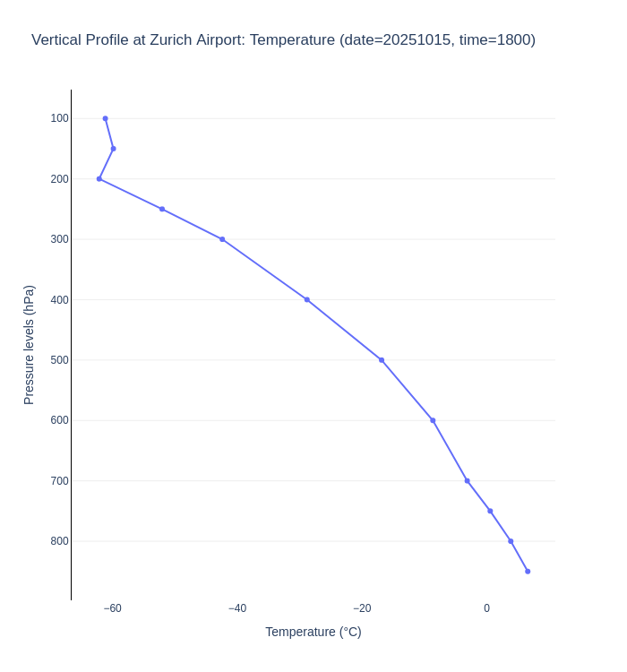

```python
chart.show("png")
```